# ship_study.csv

Autogenerated data summary from dataMaid

2021-10-14 10:56:25

# Data report overview

The dataset examined has the following dimensions:

| Feature | Result |
| --- | --- |
| Number of observations | 2154 |
| Number of variables | 29 |

### Checks performed

The following variable checks were performed, depending on the data type of each variable:

|  | character | factor | labelled | haven labelled | numeric | integer | logical | Date |
| --- | --- | --- | --- | --- | --- | --- | --- | --- |
| Identify miscoded missing values | × | × | × | × | × | × |  | × |
| Identify prefixed and suffixed whitespace | × | × | × | × |  |  |  |  |
| Identify levels with < 6 obs. | × | × | × | × |  |  |  |  |
| Identify case issues | × | × | × | × |  |  |  |  |
| Identify misclassified numeric or integer variables | × | × | × | × |  |  |  |  |
| Identify outliers |  |  |  |  | × | × |  | × |

Please note that all numerical values in the following have been rounded to 2 decimals.

# Summary table

|  | Variable class | # unique values | Missing observations | Any problems? |
| --- | --- | --- | --- | --- |
| id | integer | 2154 | 0.00 % |  |
| exdate | character | 688 | 0.00 % | × |
| age | integer | 64 | 0.00 % |  |
| sex | integer | 2 | 0.00 % |  |
| obs_bp | integer | 11 | 0.00 % | × |
| obs_soma | integer | 9 | 0.00 % | × |
| obs_int | integer | 14 | 0.00 % | × |
| dev_bp | integer | 12 | 0.00 % | × |
| dev_length | integer | 4 | 0.00 % | × |
| dev_weight | integer | 4 | 0.00 % | × |
| sbp1 | integer | 126 | 0.09 % | × |
| sbp2 | integer | 124 | 0.28 % | × |
| dbp1 | integer | 76 | 0.09 % | × |
| dbp2 | integer | 72 | 0.28 % | × |
| height | integer | 53 | 0.14 % | × |
| weight | numeric | 1764 | 0.19 % | × |
| waist | character | 2106 | 0.14 % | × |
| cholesterol | numeric | 1669 | 0.70 % | × |
| hdl | numeric | 1112 | 0.74 % | × |
| ldl | numeric | 2126 | 1.30 % | × |
| school | integer | 7 | 0.00 % | × |
| family | integer | 7 | 0.00 % | × |
| smoking | integer | 5 | 0.00 % |  |
| myocard | integer | 5 | 0.00 % |  |
| stroke | integer | 5 | 0.00 % | × |
| diab_known | integer | 3 | 0.00 % |  |
| diab_age | integer | 49 | 0.00 % | × |
| contraception | integer | 4 | 0.00 % | × |
| income | integer | 5 | 0.00 % |  |

# Variable list

## id

| Feature | Result |
| --- | --- |
| Variable type | integer |
| Number of missing obs. | 0 (0 %) |
| Number of unique values | 2154 |
| Median | 5428.5 |
| 1st and 3rd quartiles | 4356; 6490.75 |
| Min. and max. | 3301; 7607 |

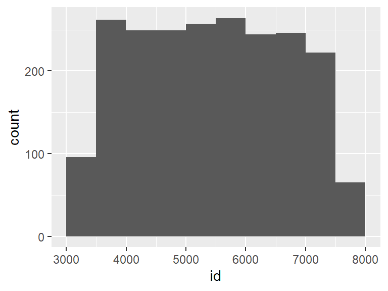